# Purrr07 - List Columns

Dookyung Kim

2018-07-13

## List columns

Data frame are not limited to atomic vectors. They can host general vectors, i.e. *lists* as well. This is what I call a **list-column**.

To work comfortably with list-columns, you need to develop techniques to:

- **Inspect**. What have I created?
- **Index**. How do I pull out specific bits by name or position?
- **Compute**. How do I operate on my list-column to make another vector or list-column?
- **Simplify**. How do I get rid of this list-column and back to a normal data frame?

### Regex and Trump tweets

#### Load packages

```r
library(tidyverse)
library(stringr)
library(lubridate)
library(here) ## devtools::install_github("r-lib/here")
```

```
#> Error in library(here): there is no package called 'here'
```

#### Bring tweets in

Working with the same 7 tweets as Trump Android words lesson. Go there for the rationale for choosing these 7 tweets.

```r
tb_raw <- read_csv(here("static","note","data", "trump-tweets.csv"))
```

```
#> Error in here("static", "note", "data", "trump-tweets.csv"): unused arguments ("static", "note", "data", "trump-tweets.csv")
```

#### Create a list-column of Trump Android words

Clean a variable and create a list-column:

- `source` comes in an unfriendly form. Simplify to convey if tweet came from Android or iPhone.
- `twords` are what we’ll call the “Trump Android words”. See Trump Android words lesson for backstory. **This is a list-column!**

```r
source_regex <- "android|iphone"
tword_regex <- "badly|crazy|weak|spent|strong|dumb|joke|guns|funny|dead"

tb <- tb_raw %>%
  mutate(source = str_extract(source, source_regex),
         twords = str_extract_all(tweet, tword_regex))
```

```
#> Error in eval(lhs, parent, parent): object 'tb_raw' not found
```

#### Derive new variables

Add variables, two of which are based on the `twords` list-column.

- `n`: How many twords are in the tweet?
- `hour`: At which hour of the day was the tweet?
- `start`: Start character of each tword.

```r
tb <- tb %>%
  mutate(n = lengths(twords),
         hour = hour(created),
         start = gregexpr(tword_regex, tweet))
```

```
#> Error in eval(lhs, parent, parent): object 'tb' not found
```

#### Use regular data manipulation toolkit

Let’s isolate tweets created before 2pm, containing 1 or 2 twords, in which there’s an tword that starts within the first 30 characters.

```r
tb %>%
  filter(hour < 14,
         between(n, 1, 2),
         between(map_int(start, min), 0, 30))
```

```
#> Error in eval(lhs, parent, parent): object 'tb' not found
```

Let’s isolate tweets that contain both the twords “strong” and “weak”.

```r
tb %>%
  filter(map_lgl(twords, ~ all(c("strong", "weak") %in% .x)))
```

```
#> Error in eval(lhs, parent, parent): object 'tb' not found
```

### JSON from an API and Game of Thrones

#### Load packages

```r
library(repurrrsive)
library(tidyverse)
library(httr)
library(stringr)
library(here)
```

```
#> Error in library(here): there is no package called 'here'
```

#### Call the API of Ice and Fire

Here’s a simplified version of how we obtained the data on the Game of Thrones POV characters. This data appears as a more processed list in the [repurrrsive](https://github.com/jennybc/repurrrsive#readme) package.

- Get character IDs from repurrrsive. *cheating a little, humor me*
- Put IDs and character names in a tibble.

```r
pov <- set_names(map_int(got_chars, "id"),
                 map_chr(got_chars, "name"))
tail(pov, 5)
```

```
#>      Melisandre    Merrett Frey Quentyn Martell   Samwell Tarly
#>             743             751             844             954
#>     Sansa Stark
#>             957
```

```r
ice <- pov %>%
  enframe(value = "id")
ice
```

```
#> # A tibble: 30 x 2
#>    name                  id
#>    <chr>              <int>
#>  1 Theon Greyjoy       1022
#>  2 Tyrion Lannister    1052
#>  3 Victarion Greyjoy   1074
#>  4 Will                1109
#>  5 Areo Hotah          1166
#>  6 Chett               1267
#>  7 Cressen             1295
#>  8 Arianne Martell      130
#>  9 Daenerys Targaryen  1303
#> 10 Davos Seaworth      1319
#> # ... with 20 more rows
```

Request info for each character and store what comes back – whatever that may be – in the list-column `stuff`.

```r
ice_and_fire_url <- "https://anapioficeandfire.com/"
if (file.exists(here("static","note","data", "ice.rds"))) {
  ice <- readRDS(here("static","note","data", "ice.rds"))
} else {
  ice <- ice %>%
    mutate(
      response = map(id,
                     ~ GET(ice_and_fire_url,
                           path = c("api", "characters", .x))),
      stuff = map(response, ~ content(.x, as = "parsed",
                                      simplifyVector = TRUE))
    ) %>%
    select(-id, -response)
  saveRDS(ice, here("static","note","data", "ice.rds"))
}
```

```
#> Error in here("static", "note", "data", "ice.rds"): unused arguments ("static", "note", "data", "ice.rds")
```

```r
ice
```

```
#> # A tibble: 30 x 2
#>    name                  id
#>    <chr>              <int>
#>  1 Theon Greyjoy       1022
#>  2 Tyrion Lannister    1052
#>  3 Victarion Greyjoy   1074
#>  4 Will                1109
#>  5 Areo Hotah          1166
#>  6 Chett               1267
#>  7 Cressen             1295
#>  8 Arianne Martell      130
#>  9 Daenerys Targaryen  1303
#> 10 Davos Seaworth      1319
#> # ... with 20 more rows
```

Let’s switch to a nicer version of `ice`, based on the list in repurrrsive, because it already has books and houses replaced with names instead of URLs.

```r
ice2 <- tibble(
  name = map_chr(got_chars, "name"),
  stuff = got_chars
)
ice2
```

```
#> # A tibble: 30 x 2
#>    name               stuff
#>    <chr>              <list>
#>  1 Theon Greyjoy      <list [18]>
#>  2 Tyrion Lannister   <list [18]>
#>  3 Victarion Greyjoy  <list [18]>
#>  4 Will               <list [18]>
#>  5 Areo Hotah         <list [18]>
#>  6 Chett              <list [18]>
#>  7 Cressen            <list [18]>
#>  8 Arianne Martell    <list [18]>
#>  9 Daenerys Targaryen <list [18]>
#> 10 Davos Seaworth     <list [18]>
#> # ... with 20 more rows
```

Inspect the list-column.

```r
str(ice2$stuff[[9]], max.level = 1)
```

```
#> List of 18
#>  $ url        : chr "https://www.anapioficeandfire.com/api/characters/1303"
#>  $ id         : int 1303
#>  $ name       : chr "Daenerys Targaryen"
#>  $ gender     : chr "Female"
#>  $ culture    : chr "Valyrian"
#>  $ born       : chr "In 284 AC, at Dragonstone"
#>  $ died       : chr ""
#>  $ alive      : logi TRUE
#>  $ titles     : chr [1:5] "Queen of the Andals and the Rhoynar and the First Men, Lord of the Seven Kingdoms" "Khaleesi of the Great Grass Sea" "Breaker of Shackles/Chains" "Queen of Meereen" ...
#>  $ aliases    : chr [1:11] "Dany" "Daenerys Stormborn" "The Unburnt" "Mother of Dragons" ...
#>  $ father     : chr ""
#>  $ mother     : chr ""
#>  $ spouse     : chr "https://www.anapioficeandfire.com/api/characters/1346"
#>  $ allegiances: chr "House Targaryen of King's Landing"
#>  $ books      : chr "A Feast for Crows"
#>  $ povBooks   : chr [1:4] "A Game of Thrones" "A Clash of Kings" "A Storm of Swords" "A Dance with Dragons"
#>  $ tvSeries   : chr [1:6] "Season 1" "Season 2" "Season 3" "Season 4" ...
#>  $ playedBy   : chr "Emilia Clarke"
```

```r
# if (interactive()) {
#   listviewer::jsonedit(ice2$stuff[[2]], mode = "view", width = 500, height = 530)
# }
```

### Use regular data manipulation toolkit

Form a sentence of the form “NAME was born AT THIS TIME, IN THIS PLACE” by digging info out of the `stuff` list-column and placing into a string template. No list-columns left!

```r
template <- "${name} was born ${born}."
birth_announcements <- ice2 %>%
  mutate(birth = map_chr(stuff, str_interp, string = template)) %>%
  select(-stuff)
birth_announcements
```

```
#> # A tibble: 30 x 2
#>    name               birth
#>    <chr>              <chr>
#>  1 Theon Greyjoy      Theon Greyjoy was born In 278 AC or 279 AC, at Pyke.
#>  2 Tyrion Lannister   Tyrion Lannister was born In 273 AC, at Casterly Ro…
#>  3 Victarion Greyjoy  Victarion Greyjoy was born In 268 AC or before, at …
#>  4 Will               Will was born .
#>  5 Areo Hotah         Areo Hotah was born In 257 AC or before, at Norvos.
#>  6 Chett              Chett was born At Hag's Mire.
#>  7 Cressen            Cressen was born In 219 AC or 220 AC.
#>  8 Arianne Martell    Arianne Martell was born In 276 AC, at Sunspear.
#>  9 Daenerys Targaryen Daenerys Targaryen was born In 284 AC, at Dragonsto…
#> 10 Davos Seaworth     Davos Seaworth was born In 260 AC or before, at Kin…
#> # ... with 20 more rows
```

Extract each character’s house allegiances. Keep only those with more than one allegiance. Then unnest to explode the `houses` list-column and get a tibble with one row per character * house combination. No list-columns left!

```r
allegiances <- ice2 %>%
  transmute(name,
            houses = map(stuff, "allegiances")) %>%
  filter(lengths(houses) > 1) %>%
  unnest()
allegiances
```

```
#> # A tibble: 15 x 2
#>    name             houses
#>    <chr>            <chr>
#>  1 Davos Seaworth   House Baratheon of Dragonstone
#>  2 Davos Seaworth   House Seaworth of Cape Wrath
#>  3 Asha Greyjoy     House Greyjoy of Pyke
#>  4 Asha Greyjoy     House Ironmaker
#>  5 Barristan Selmy  House Selmy of Harvest Hall
#>  6 Barristan Selmy  House Targaryen of King's Landing
#>  7 Brienne of Tarth House Baratheon of Storm's End
#>  8 Brienne of Tarth House Stark of Winterfell
#>  9 Brienne of Tarth House Tarth of Evenfall Hall
#> 10 Catelyn Stark    House Stark of Winterfell
#> 11 Catelyn Stark    House Tully of Riverrun
#> 12 Jon Connington   House Connington of Griffin's Roost
#> 13 Jon Connington   House Targaryen of King's Landing
#> 14 Sansa Stark      House Baelish of Harrenhal
#> 15 Sansa Stark      House Stark of Winterfell
```

### Aliases and allegiances of Game of Thrones characters

#### Load packages

```r
library(tidyverse)
library(repurrrsive)
library(stringr)
```

#### Lists as variables in a data frame

One row per GoT character. List columns for aliases and allegiances.

```r
x <- tibble(
  name = got_chars %>% map_chr("name"),
  aliases = got_chars %>% map("aliases"),
  allegiances = got_chars %>% map("allegiances")
)
x
```

```
#> # A tibble: 30 x 3
#>    name               aliases    allegiances
#>    <chr>              <list>     <list>
#>  1 Theon Greyjoy      <chr [4]>  <chr [1]>
#>  2 Tyrion Lannister   <chr [11]> <chr [1]>
#>  3 Victarion Greyjoy  <chr [1]>  <chr [1]>
#>  4 Will               <chr [1]>  <NULL>
#>  5 Areo Hotah         <chr [1]>  <chr [1]>
#>  6 Chett              <chr [1]>  <NULL>
#>  7 Cressen            <chr [1]>  <NULL>
#>  8 Arianne Martell    <chr [1]>  <chr [1]>
#>  9 Daenerys Targaryen <chr [11]> <chr [1]>
#> 10 Davos Seaworth     <chr [5]>  <chr [2]>
#> # ... with 20 more rows
```

```r
#View(x)
```

What if we only care about characters with a “Lannister” alliance? Practice operating on a list-column.

```r
x %>%
  mutate(lannister = map(allegiances, str_detect, pattern = "Lannister"),
         lannister = map_lgl(lannister, any))
```

```
#> # A tibble: 30 x 4
#>    name               aliases    allegiances lannister
#>    <chr>              <list>     <list>      <lgl>
#>  1 Theon Greyjoy      <chr [4]>  <chr [1]>   FALSE
#>  2 Tyrion Lannister   <chr [11]> <chr [1]>   TRUE
#>  3 Victarion Greyjoy  <chr [1]>  <chr [1]>   FALSE
#>  4 Will               <chr [1]>  <NULL>      FALSE
#>  5 Areo Hotah         <chr [1]>  <chr [1]>   FALSE
#>  6 Chett              <chr [1]>  <NULL>      FALSE
#>  7 Cressen            <chr [1]>  <NULL>      FALSE
#>  8 Arianne Martell    <chr [1]>  <chr [1]>   FALSE
#>  9 Daenerys Targaryen <chr [11]> <chr [1]>   FALSE
#> 10 Davos Seaworth     <chr [5]>  <chr [2]>   FALSE
#> # ... with 20 more rows
```

Keep only the Lannisters and Starks allegiances. You can use `filter()` with list-columns, but you will need to `map()` to list-ize your operation. Once I’ve got the characters I want, I drop `allegiances` and use `unnest()` to get back to a simple data frame with no list columns.

```r
x %>%
  filter(allegiances %>%
           map(str_detect, "Lannister|Stark") %>%
           map_lgl(any)) %>%
  select(-allegiances) %>%
  filter(lengths(aliases) > 0) %>%
  unnest() %>%
  print(n = Inf)
```

```
#> # A tibble: 57 x 2
#>    name             aliases
#>    <chr>            <chr>
#>  1 Tyrion Lannister The Imp
#>  2 Tyrion Lannister Halfman
#>  3 Tyrion Lannister The boyman
#>  4 Tyrion Lannister Giant of Lannister
#>  5 Tyrion Lannister Lord Tywin's Doom
#>  6 Tyrion Lannister Lord Tywin's Bane
#>  7 Tyrion Lannister Yollo
#>  8 Tyrion Lannister Hugor Hill
#>  9 Tyrion Lannister No-Nose
#> 10 Tyrion Lannister Freak
#> 11 Tyrion Lannister Dwarf
#> 12 Arya Stark       Arya Horseface
```

[output cut: 45 more lines]

### Nested data frame, modelling, and Gapminder

Another version of this same example is here:

http://r4ds.had.co.nz/many-models.html

*mostly code at this point, more words needed*

#### Load packages

```r
library(tidyverse)
library(gapminder)
library(broom)
```

### Hello, again, Gapminder

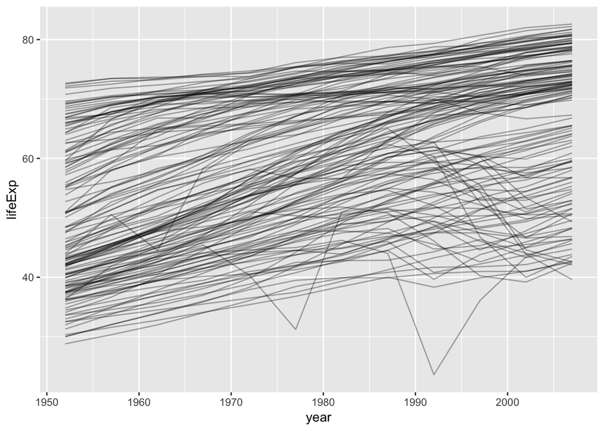

```r
gapminder %>%
  ggplot(aes(year, lifeExp, group = country)) +
    geom_line(alpha = 1/3)
```

What if we fit a line to each country?

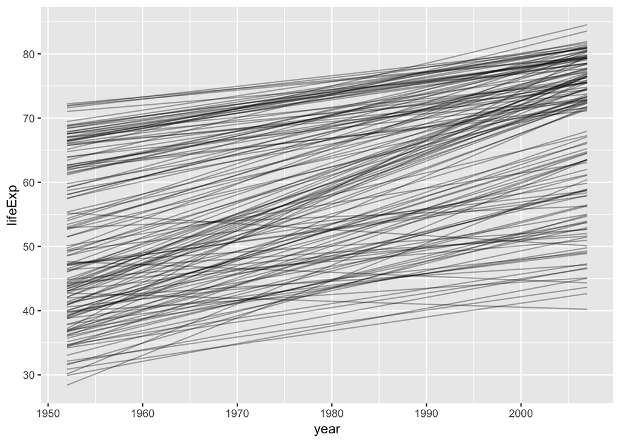

```r
gapminder %>%
  ggplot(aes(year, lifeExp, group = country)) +
  geom_line(stat = "smooth", method = "lm",
            alpha = 1/3, se = FALSE, colour = "black")
```

What if you actually want those fits? To access estimates, p-values, etc. In that case, you need to fit them yourself. How to do that?

- Put the variables needed for country-specific models into nested dataframe. In a **list-column**!
- Use the usual “map inside mutate”, possibly with the broom package, to pull interesting information out of the 142 fitted linear models.

#### Nested data frame

Nest the data frames, i.e. get one meta-row per country:

```r
gap_nested <- gapminder %>%
  group_by(country) %>%
  nest()
gap_nested
```

```
#> # A tibble: 142 x 2
#>    country     data
#>    <fct>       <list>
#>  1 Afghanistan <tibble [12 × 5]>
#>  2 Albania     <tibble [12 × 5]>
#>  3 Algeria     <tibble [12 × 5]>
#>  4 Angola      <tibble [12 × 5]>
#>  5 Argentina   <tibble [12 × 5]>
#>  6 Australia   <tibble [12 × 5]>
#>  7 Austria     <tibble [12 × 5]>
#>  8 Bahrain     <tibble [12 × 5]>
#>  9 Bangladesh  <tibble [12 × 5]>
#> 10 Belgium     <tibble [12 × 5]>
#> # ... with 132 more rows
```

```r
gap_nested$data[[1]]
```

```
#> # A tibble: 12 x 5
#>    continent  year lifeExp      pop gdpPercap
#>    <fct>     <int>   <dbl>    <int>     <dbl>
#>  1 Asia       1952    28.8  8425333      779.
#>  2 Asia       1957    30.3  9240934      821.
#>  3 Asia       1962    32.0 10267083      853.
#>  4 Asia       1967    34.0 11537966      836.
#>  5 Asia       1972    36.1 13079460      740.
#>  6 Asia       1977    38.4 14880372      786.
#>  7 Asia       1982    39.9 12881816      978.
#>  8 Asia       1987    40.8 13867957      852.
#>  9 Asia       1992    41.7 16317921      649.
#> 10 Asia       1997    41.8 22227415      635.
#> 11 Asia       2002    42.1 25268405      727.
#> 12 Asia       2007    43.8 31889923      975.
```

*Compare/contrast to a data frame grouped by country (dplyr-style) or split on country (base)*.

#### Fit models, extract results

Fit a model for each country.

```r
gap_fits <- gap_nested %>%
  mutate(fit = map(data, ~ lm(lifeExp ~ year, data = .x)))
```

Look at one fitted model, for concreteness.

```r
gap_fits %>% tail(3)
```

```
#> # A tibble: 3 x 3
#>   country     data              fit
#>   <fct>       <list>            <list>
#> 1 Yemen, Rep. <tibble [12 × 5]> <S3: lm>
#> 2 Zambia      <tibble [12 × 5]> <S3: lm>
#> 3 Zimbabwe    <tibble [12 × 5]> <S3: lm>
```

```r
canada <- which(gap_fits$country == "Canada")
summary(gap_fits$fit[[canada]])
```

```
#>
#> Call:
#> lm(formula = lifeExp ~ year, data = .x)
#>
#> Residuals:
#>     Min      1Q  Median      3Q     Max
#> -0.3812 -0.1368 -0.0471  0.2481  0.3157
#>
#> Coefficients:
#>               Estimate Std. Error t value Pr(>|t|)
#> (Intercept) -3.583e+02  8.252e+00  -43.42 1.01e-12 ***
#> year         2.189e-01  4.169e-03   52.50 1.52e-13 ***
#> ---
#> Signif. codes:  0 '***' 0.001 '**' 0.01 '*' 0.05 '.' 0.1 ' ' 1
#>
#> Residual standard error: 0.2492 on 10 degrees of freedom
#> Multiple R-squared:  0.9964, Adjusted R-squared:  0.996
#> F-statistic:  2757 on 1 and 10 DF,  p-value: 1.521e-13
```

Let’s get all the r-squared values!

```r
gap_fits %>%
  mutate(rsq = map_dbl(fit, ~ summary(.x)[["r.squared"]])) %>%
  arrange(rsq)
```

```
#> # A tibble: 142 x 4
#>    country          data              fit         rsq
#>    <fct>            <list>            <list>    <dbl>
#>  1 Rwanda           <tibble [12 × 5]> <S3: lm> 0.0172
#>  2 Botswana         <tibble [12 × 5]> <S3: lm> 0.0340
#>  3 Zimbabwe         <tibble [12 × 5]> <S3: lm> 0.0562
#>  4 Zambia           <tibble [12 × 5]> <S3: lm> 0.0598
#>  5 Swaziland        <tibble [12 × 5]> <S3: lm> 0.0682
#>  6 Lesotho          <tibble [12 × 5]> <S3: lm> 0.0849
#>  7 Cote d'Ivoire    <tibble [12 × 5]> <S3: lm> 0.283
#>  8 South Africa     <tibble [12 × 5]> <S3: lm> 0.312
#>  9 Uganda           <tibble [12 × 5]> <S3: lm> 0.342
#> 10 Congo, Dem. Rep. <tibble [12 × 5]> <S3: lm> 0.348
#> # ... with 132 more rows
```

Let’s use a function from broom to get the usual coefficient table from `summary.lm()` but in a friendlier form for downstream work.

```r
library(broom)
gap_fits %>%
  mutate(coef = map(fit, tidy)) %>%
  unnest(coef)
```

```
#> # A tibble: 284 x 6
#>    country     term         estimate std.error statistic  p.value
#>    <fct>       <chr>           <dbl>     <dbl>     <dbl>    <dbl>
#>  1 Afghanistan (Intercept)  -508.     40.5        -12.5  1.93e- 7
#>  2 Afghanistan year            0.275   0.0205      13.5  9.84e- 8
#>  3 Albania     (Intercept)  -594.     65.7         -9.05 3.94e- 6
#>  4 Albania     year            0.335   0.0332      10.1  1.46e- 6
#>  5 Algeria     (Intercept) -1068.     43.8        -24.4  3.07e-10
#>  6 Algeria     year            0.569   0.0221      25.7  1.81e-10
#>  7 Angola      (Intercept)  -377.     46.6         -8.08 1.08e- 5
#>  8 Angola      year            0.209   0.0235       8.90 4.59e- 6
#>  9 Argentina   (Intercept)  -390.      9.68       -40.3  2.14e-12
#> 10 Argentina   year            0.232   0.00489     47.4  4.22e-13
#> # ... with 274 more rows
```

## Resources

[stat545, purrr, list-columns, nested data frames](http://stat545.com/cm103_list-inspection-mapping.html)

[purrr tutorial](https://jennybc.github.io/purrr-tutorial/index.html)